# Project 2

Kevin Francis

11/10/2020

# Data Description

The data I choose describes the payment required when visiting a hospital, the type of admission to the hospital, and the severity of the illness. I want to know if the price paid when arriving is dependent on the type of admission and the severity. We will start by first looking at some summary statistics. Lets looks at the two factors individually, and then in combination.

```r
data <- read.csv("test_data.csv")
admission_type_summ <- data %>%
  group_by(Type.of.Admission) %>%
  summarise(mean = mean(Admission_Deposit), sd = sd(Admission_Deposit), median = median(Admission_Deposit),   IQR = IQR(Admission_Deposit), mode = getmode(Admission_Deposit), sampeSize = length(Admission_Deposit))
severity_type_summ <- data %>%
  group_by(Severity.of.Illness) %>%
  summarise(mean = mean(Admission_Deposit), sd = sd(Admission_Deposit), median = median(Admission_Deposit),   IQR = IQR(Admission_Deposit), mode = getmode(Admission_Deposit), sampeSize = length(Admission_Deposit))
admission_severity_summ <- data %>%
  group_by(Type.of.Admission, Severity.of.Illness) %>%
  summarise(mean = mean(Admission_Deposit), sd = sd(Admission_Deposit), median = median(Admission_Deposit),   IQR = IQR(Admission_Deposit), mode = getmode(Admission_Deposit), sampeSize = length(Admission_Deposit))
#Some data cleaning to make it easier to work with
admission_type <- split.data.frame(data['Admission_Deposit'], data$Type.of.Admission)
admission_severity <- split.data.frame(data['Admission_Deposit'], data$Severity.of.Illness)
```

Mean, Standard Deviation, Median, and IQR of Admission Deposit by Admission Type

| Type of Admission | Mean | Standard Deviation | Median | IQR | Mode | Sample Size |
| --- | --- | --- | --- | --- | --- | --- |
| Emergency | 4763.402 | 1062.891 | 4641 | 1217 | 4273 | 50687 |
| Trauma | 4970.264 | 1066.169 | 4817 | 1190 | 4785 | 65411 |
| Urgent | 4813.124 | 1138.667 | 4657 | 1311 | 4966 | 20959 |

Mean, Standard Deviation, Median, and IQR of Admission Deposit by Severity

| Severity of Illness | Mean | Standard Deviation | Median | IQR | Mode | Sample Size |
| --- | --- | --- | --- | --- | --- | --- |
| Extreme | 4741.815 | 1062.913 | 4608 | 1179 | 4388 | 24472 |
| Minor | 4970.484 | 1072.474 | 4841 | 1231 | 4465 | 36863 |
| Moderate | 4862.023 | 1085.753 | 4718 | 1215 | 4465 | 75722 |

Mean, Standard Deviation, Median, and IQR of Admission Deposit by Admission Type and Severity

| Type of Admission | Severity of Illness | Mean | Standard Deviation | Median | IQR | Mode | Sample Size |
| --- | --- | --- | --- | --- | --- | --- | --- |
| Emergency | Extreme | 4618.247 | 1039.473 | 4489 | 1167.00 | 4388 | 8555 |
| Emergency | Minor | 4891.486 | 1063.297 | 4779 | 1230.00 | 4273 | 15217 |
| Emergency | Moderate | 4737.125 | 1062.223 | 4610 | 1198.00 | 4465 | 26915 |
| Trauma | Extreme | 4852.083 | 1056.730 | 4710 | 1134.00 | 4895 | 12433 |
| Trauma | Minor | 5068.944 | 1054.824 | 4931 | 1201.00 | 4620 | 15705 |
| Trauma | Moderate | 4968.106 | 1069.969 | 4811 | 1189.00 | 4785 | 37273 |
| Urgent | Extreme | 4651.737 | 1099.640 | 4523 | 1294.50 | 5537 | 3484 |
| Urgent | Minor | 4912.546 | 1120.303 | 4761 | 1288.00 | 4966 | 5941 |
| Urgent | Moderate | 4810.661 | 1153.937 | 4646 | 1315.75 | 4966 | 11534 |

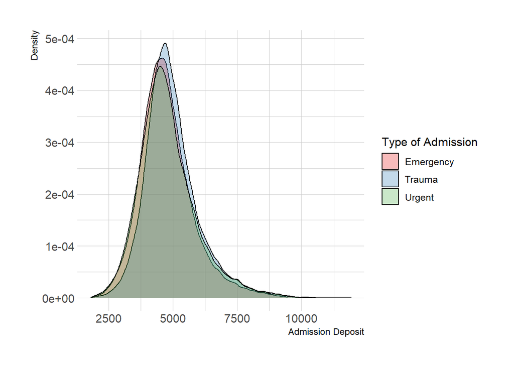

```r
ggplot(data=data, aes(x=data$Admission_Deposit, group=data$Type.of.Admission, fill=data$Type.of.Admission)) +
    geom_density(alpha=.3) +
    theme_ipsum() +
    xlab('Admission Deposit') +
    ylab('Density') + labs(fill = 'Type of Admission') +
    scale_fill_brewer(palette="Set1")
```

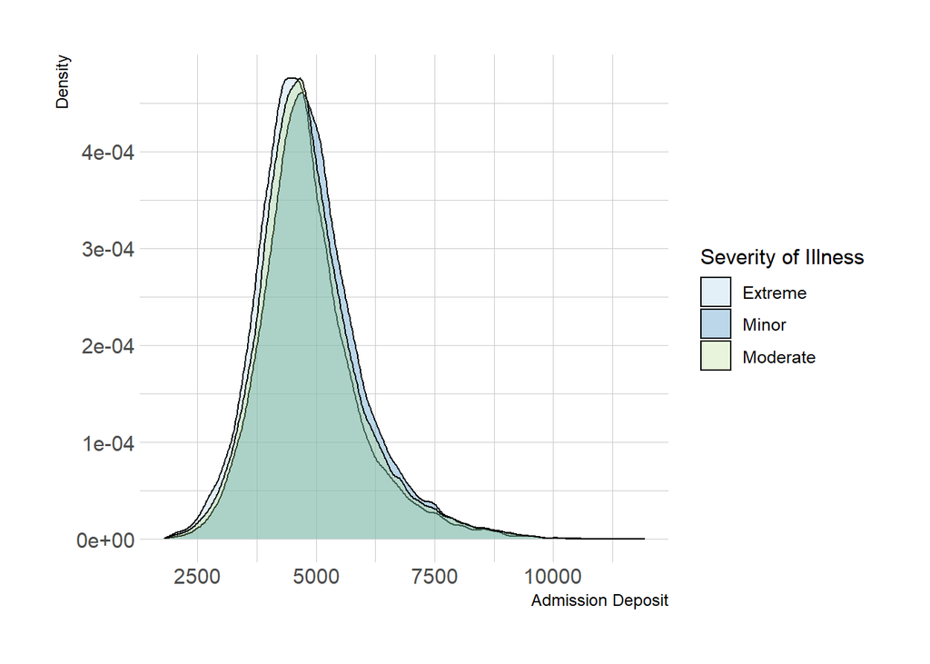

```r
ggplot(data=data, aes(x=data$Admission_Deposit, group=data$Severity.of.Illness, fill=data$Severity.of.Illness)) +
    geom_density(alpha=.3) +
    theme_ipsum() +
    xlab('Admission Deposit') +
    ylab('Density') + labs(fill = 'Severity of Illness') +
    scale_fill_brewer(palette="Paired")
```

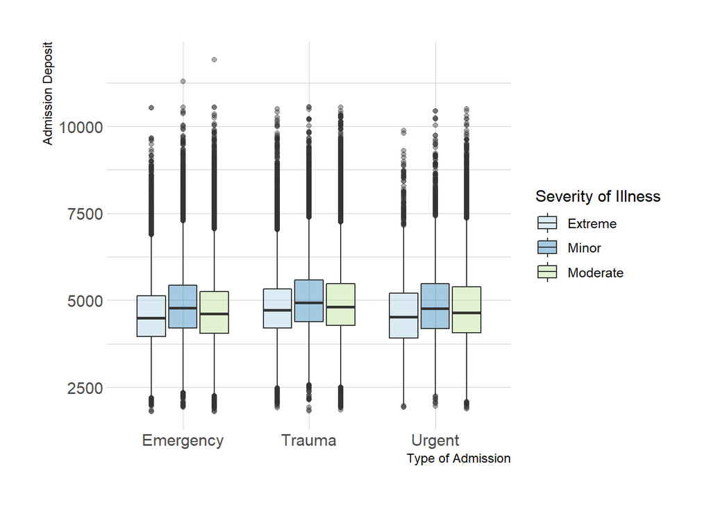

```r
ggplot(data=data, aes(x=data$Type.of.Admission, y=Admission_Deposit, fill=data$Severity.of.Illness)) +  geom_boxplot(show.legend = TRUE, alpha=.4) +
  ylab("Admission Deposit") + xlab("Type of Admission") +
  theme(plot.title = element_text(hjust = 0.5)) +
  scale_fill_brewer(palette="Paired") + theme_ipsum() + labs(fill = 'Severity of Illness')
```

The above box plot shows the range and outliers for the severity of illness grouped by type of admission. This plot also helps look at the IQR and median. Box plots can help to show extreme values and disparity between the medians.

# Tests

## One-way ANOVA

Now I will perform a one-way ANOVA test on both the severity of illness and the type of admission. This will tell us if the means of each level of severity and admission type are the same with respect to there individual groups.

```r
model1 <- aov(data$Admission_Deposit ~ data$Severity.of.Illness, data=data)
anova1 <- anova(model1)

rownames(anova1) <- c("Severity of Illness", "Error")
knitr::kable(anova1)
```

|  | Df | Sum Sq | Mean Sq | F value | Pr(>F) |
| --- | --- | --- | --- | --- | --- |
| Severity of Illness | 2 | 779121206 | 389560603 | 335.1379 | 0 |
| Error | 137054 | 159310059030 | 1162389 | NA | NA |

**Hypotheses**

$H_0: \ \mu_1 = \mu_2 = \mu_3$

$H_1:$ at least one is different

**Test Statistic**

$F_{0} = 335.138$

*p*-value

$p < 0.0001$

**Rejection Region**

Reject if $p < \alpha$, where $\alpha=0.05$.

**Conclusion and Interpretation**

Reject $H_0$. There is sufficient evidence to suggest that at least one of the average admission deposits is different based on severity of illness.

```r
model2 <- aov(data$Admission_Deposit ~ data$Type.of.Admission, data=data)
anova2 <- anova(model2)
rownames(anova2) <- c("Type of Admission", "Error")
knitr::kable(anova2)
```

|  | Df | Sum Sq | Mean Sq | F value | Pr(>F) |
| --- | --- | --- | --- | --- | --- |
| Type of Admission | 2 | 1301322918 | 650661459 | 561.6031 | 0 |
| Error | 137054 | 158787857318 | 1158579 | NA | NA |

**Hypotheses**

$H_0: \ \mu_1 = \mu_2 = \mu_3$

$H_1:$ at least one is different

**Test Statistic**

$F_{0} = 561.603$

*p*-value

$p < 0.0001$

**Rejection Region**

Reject if $p < \alpha$, where $\alpha=0.05$.

**Conclusion and Interpretation**

Reject $H_0$. There is sufficient evidence to suggest that at least one of the average admission deposits is different based on type of admission.

## Post Hoc Testing

We know from the ANOVA results that the means of admission deposit are not the same for both severity of illness and the type of admission. Now all of the pairwise contrasts will be looked at using Tukey’s test.

```r
tukey <- TukeyHSD(x=model1, 'data$Severity.of.Illness', conf.level=0.95)
tky <- as.data.frame(tukey$`data$Severity.of.Illness`)
tky$`data$Severity.of.Illness` <- rownames(tky)
```

| Comparison | p-value | Significant? |
| --- | --- | --- |
| Minor vs. Extreme | 0.0000 | Yes |
| Moderate vs. Extreme | 0.0000 | Yes |
| Moderate vs. Minor | 0.0000 | Yes |

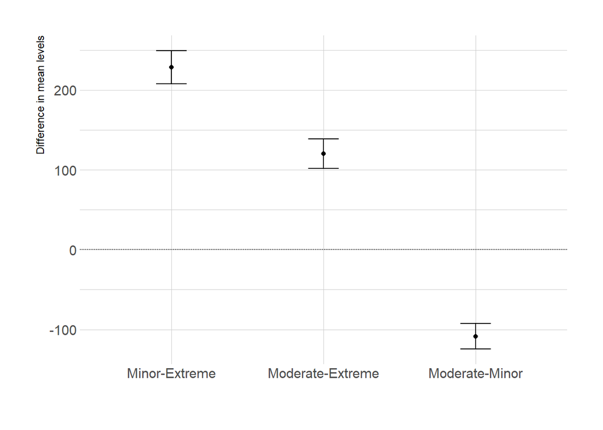

```r
ggplot(tky) +
  geom_errorbar(aes(tky$`data$Severity.of.Illness`, ymin=tky$lwr, ymax=tky$upr), width=0.2) +
  geom_point(aes(tky$`data$Severity.of.Illness`, tky$diff)) +
  theme_ipsum() + ylab("Difference in mean levels") + xlab("") +
  geom_hline(yintercept=0, lty="11", colour="grey30") +
  theme(plot.title = element_text(hjust = 0.5))
```

```r
tukey <- TukeyHSD(x=model2, 'data$Type.of.Admission', conf.level=0.95)
tky <- as.data.frame(tukey$`data$Type.of.Admission`)
tky$`data$Type.of.Admission` <- rownames(tky)
```

| Comparison | p-value | Significant? |
| --- | --- | --- |
| Trauma vs. Emergency | 0.0000 | Yes |
| Urgent vs. Emergency | 0.0000 | Yes |
| Urgent vs. Trauma | 0.0000 | Yes |

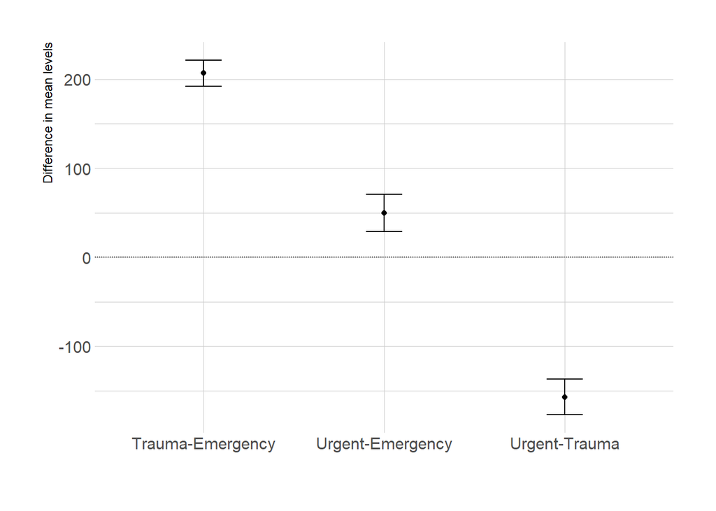

```r
ggplot(tky) +
  geom_errorbar(aes(tky$`data$Type.of.Admission`, ymin=tky$lwr, ymax=tky$upr), width=0.2) +
  geom_point(aes(tky$`data$Type.of.Admission`, tky$diff)) +
  theme_ipsum() + ylab("Difference in mean levels") + xlab("") +
  geom_hline(yintercept=0, lty="11", colour="grey30") +
  theme(plot.title = element_text(hjust = 0.5))
```

These plots tell us that the means can not be assumed equal for any combination of two groups, with respect to the parent group the belong to (severity or admission type). This is a visual representation of checking if $p < .05$. If the vertical lines do not cover the horizontal line, which is zero for these plots, then that interaction is significant. Something to note, the p-values for all of the interactions from both groups was so small that it returned zero.

## One-way ANOVA Assumptions

Now lets verify the ANOVA assumptions. I want to see if the residuals (errors) model a normal distribution with a mean of zero and a constant variance.

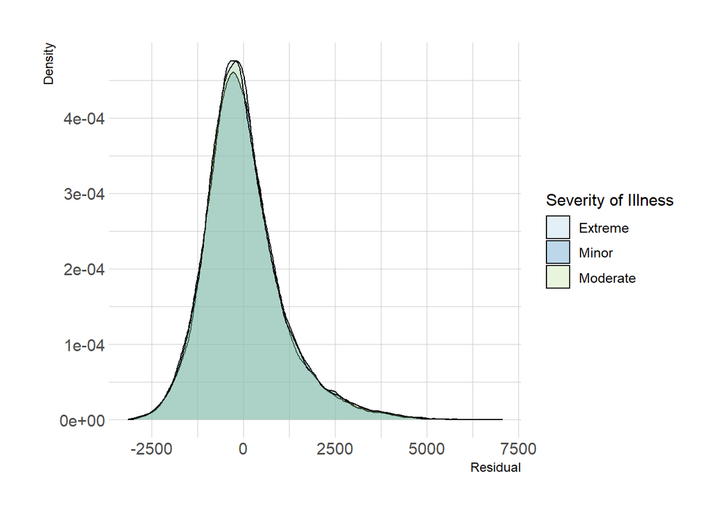

```r
res1 <- resid(model1)
res2 <- resid(model2)

ggplot(data=data, aes(x=res1, group=Severity.of.Illness, fill=Severity.of.Illness)) +
    geom_density(alpha=.3) +
    theme_ipsum() +
    xlab('Residual') +
    ylab('Density') + labs(fill = 'Severity of Illness') +
    scale_fill_brewer(palette="Paired")
```

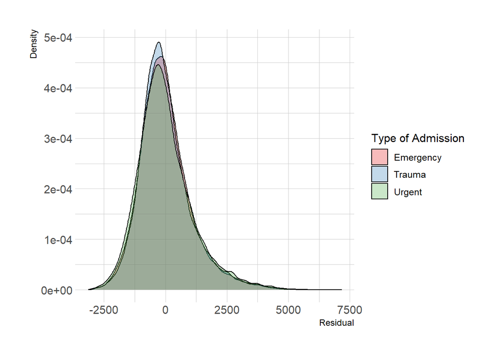

```r
ggplot(data=data, aes(x=res2, group=Type.of.Admission, fill=Type.of.Admission)) +
    geom_density(alpha=.3) +
    theme_ipsum() +
    xlab('Residual') +
    ylab('Density') + labs(fill = 'Type of Admission') +
    scale_fill_brewer(palette="Set1")
```

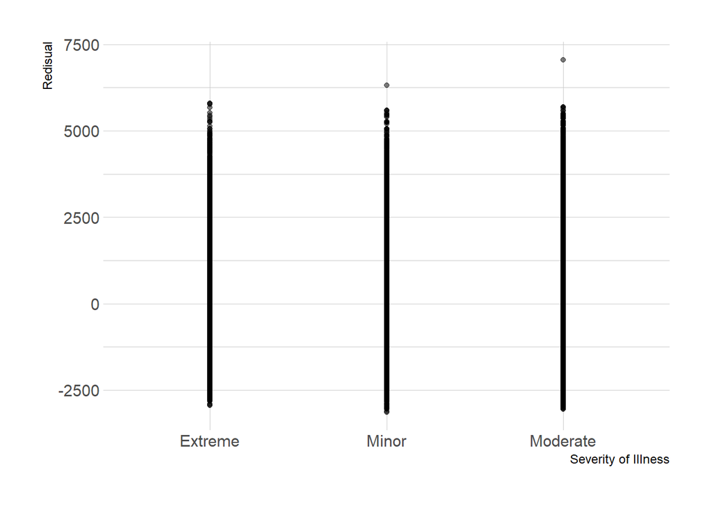

```r
ggplot(data=data, aes(y=res1, x=Severity.of.Illness, fill=Severity.of.Illness)) +
    geom_point(alpha=.5) +
    theme_ipsum() +
    xlab('Severity of Illness') +
    ylab('Redisual') + theme(legend.position = "none")
```

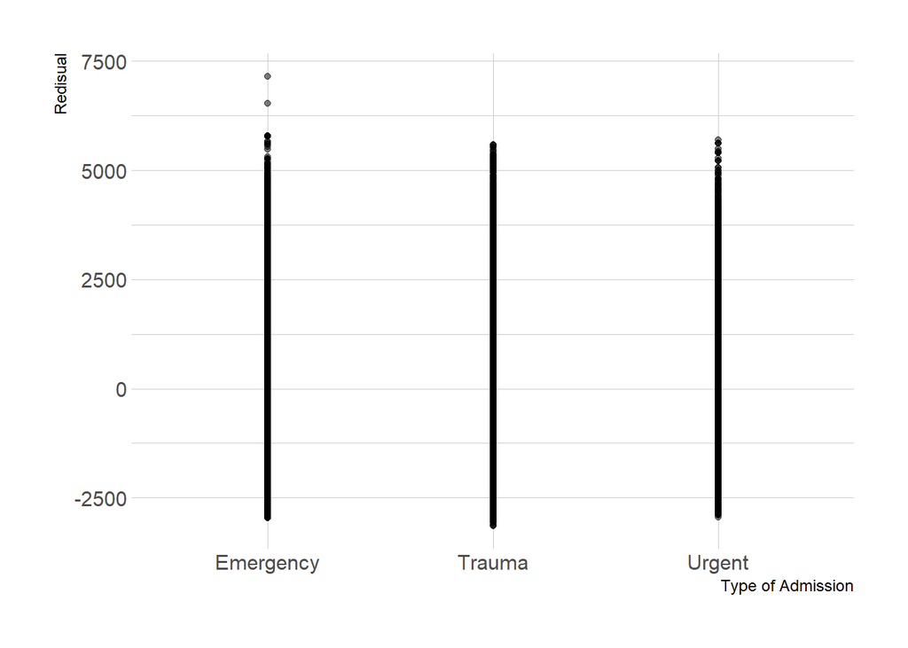

```r
ggplot(data=data, aes(y=res2, x=Type.of.Admission, fill=Type.of.Admission)) +
    geom_point(alpha=.5) +
    theme_ipsum() +
    xlab('Type of Admission') +
    ylab('Redisual') + theme(legend.position = "none")
```

These two plots are used to look at the variance. We say that the variance across the subgroups should be constant. These plots imply that is true. This is because the vertical lines are about the same length.

## Two-way ANOVA

**Hypotheses**

$H_0:$ There is not an interaction between severity of illness and type of admission

$H_1:$ There is an interaction between severity of illness and type of admission

```r
model3 <- aov(data$Admission_Deposit ~ data$Severity.of.Illness * data$Type.of.Admission, data=data)
anova_two <- anova(model3)

rownames(anova_two) <- c("Severity of Illness", "Type of Admission", "Severity and Admission Type", "Error")
knitr::kable(anova_two)
```

|  | Df | Sum Sq | Mean Sq | F value | Pr(>F) |
| --- | --- | --- | --- | --- | --- |
| Severity of Illness | 2 | 779121206 | 389560603 | 338.19497 | 0.000000 |
| Type of Admission | 2 | 1425631148 | 712815574 | 618.82706 | 0.000000 |
| Severity and Admission Type | 4 | 21342848 | 5335712 | 4.63217 | 0.000973 |
| Error | 137048 | 157863085034 | 1151882 | NA | NA |

**Test Statistic**

$F_{0} = 4.632$

*p*-value

$p = 0.001$

**Rejection Region**

Reject if $p < \alpha$, where $\alpha=0.05$.

**Conclusion and Interpretation**

Reject $H_0$. There is sufficient evidence to suggest that there is an interaction between severity of illness and type of admission.

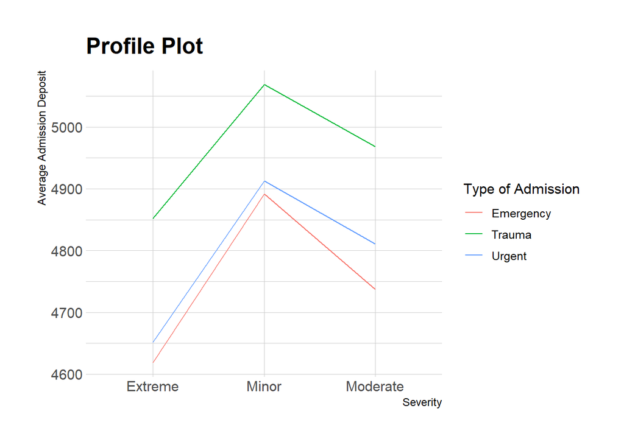

```r
prof_data <- data %>%
  group_by(Severity.of.Illness, Type.of.Admission) %>%
  summarise_at(vars(Admission_Deposit), funs(mean(., na.rm=TRUE)))

ggplot(data=prof_data, aes(x = prof_data$Severity.of.Illness, y = prof_data$Admission_Deposit,              group=prof_data$Type.of.Admission, color=prof_data$Type.of.Admission)) +
    geom_line() +
    theme_ipsum() +
    xlab('Severity') +
    ylab('Average Admission Deposit') + labs(color = 'Type of Admission') +
    ggtitle('Profile Plot')
```

The profile plot does not show the interaction the two-way ANOVA test found. This is because of the size of the dataset. When there is this much data a small interaction can cause the ANOVA test to be rejected. However, the interaction might not be significant enough to matter or even show up in the profile plot. Due to the plot showing the interaction is not significant, I will now look at ANOVA without the interaction.

```r
model4 <- aov(data$Admission_Deposit ~ data$Severity.of.Illness+data$Type.of.Admission, data = data)
anova_two_no <- anova(model4)
rownames(anova_two_no) <- c("Severity of Illness", "Type of Admission", "Error")
knitr::kable(anova_two_no)
```

|  | Df | Sum Sq | Mean Sq | F value | Pr(>F) |
| --- | --- | --- | --- | --- | --- |
| Severity of Illness | 2 | 779121206 | 389560603 | 338.1591 | 0 |
| Type of Admission | 2 | 1425631148 | 712815574 | 618.7615 | 0 |
| Error | 137052 | 157884427883 | 1152004 | NA | NA |

### Two-way ANOVA Without Interactions

**Hypotheses**

$H_0:$ There is not a main effect of severity of illness $H_1:$ There is a main effect of severity of illness

**Test Statistic**

$F_{0} = 338.159$

*p*-value

$p < 0.0001$

**Rejection Region**

Reject if $p < \alpha$, where $\alpha=0.05$.

**Conclusion and Interpretation**

Reject $H_0$. There is sufficient evidence to suggest that there is a main effect of severity of illness.

**Hypotheses**

$H_0:$ There is not a main effect of type of admission $H_1:$ There is a main effect of type of admission

**Test Statistic**

$F_{0} = 618.761$

*p*-value

$p < 0.0001$

**Rejection Region**

Reject if $p < \alpha$, where $\alpha=0.05$.

**Conclusion and Interpretation**

Reject $H_0$. There is sufficient evidence to suggest that there is a main effect of type of admission.

## Two-way ANOVA Assumptions

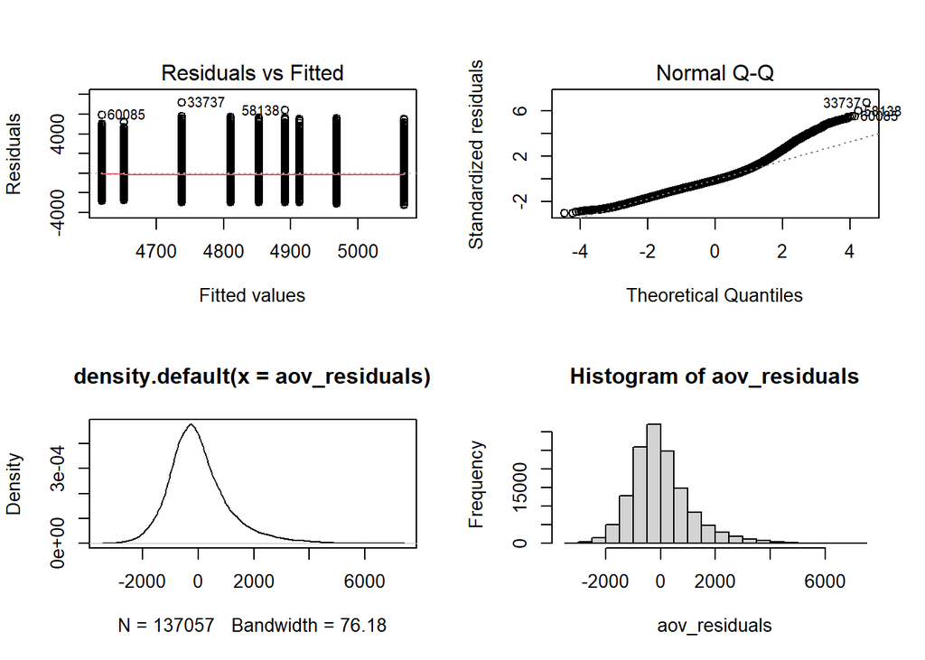

```r
almost_sas(model3)
```